# Kongerækken W10

Josefine Dresler

05-03-2025

The task here is to load your Danish Monarchs csv into R using the `tidyverse` toolkit, calculate and explore the kings’ duration of reign with pipes `%>%` in `dplyr` and plot it over time.

## Load the kings

Make sure to first create an `.Rproj` workspace with a `data/` folder where you place either your own dataset or the provided `kings.csv` dataset.

1. Look at the dataset that are you loading and check what its columns are separated by? (hint: open it in plain text editor to see)

2. Create a `kings` object in R with the different functions below and inspect the different outputs.
- `read.csv()`
- `read_csv()`
- `read.csv2()`
- `read_csv2()`

```r
# FILL IN THE CODE BELOW and review the outputs
kings1 <- read.csv2("/Users/user/Desktop/Historie AU/2. Semester/Digitale_arkiver_metoder/kongerækken-csv-2.csv")
head(kings1)
```

```
##                Monark Født  Død          Slægt Regerings.start Regering.slut
## 1      Gorm den gamle   NA   NA Jellingekonger             958            NA
## 2 Harald (1.) Blåtand   NA  987 Jellingekonger             958           987
## 3  Svend (1.) Tveskæg   NA 1014 Jellingekonger             987          1014
## 4 Harald (2.) Svensen   NA 1018 Jellingekonger            1014          1018
## 5 Knud (2.) den Store  995 1035 Jellingekonger            1018          1035
## 6 Hardeknud (Knud 3.) 1020 1042 Jellingekonger            1035          1042
##   Regeringsperioder Anden.periodestart Anden.periode.slut Regerings.år.i.alt
## 1                 1                Nej                Nej                 NA
## 2                 1                Nej                Nej                 29
## 3                 1                Nej                Nej                 27
## 4                 1                Nej                Nej                  4
## 5                 1                Nej                Nej                 17
## 6                 1                Nej                Nej                  7
##             Gift.med Født.1 Død.1         Kone.2 Født.2 Død.2 Kone.3 Født.3
## 1      Thyra Danebod     NA   950            Nej    Nej  Nej     Nej    Nej
## 2            Gunhild     NA  <NA> Tove af Verden   <NA>  <NA>    Nej    Nej
## 3   Gunhild af Polen     NA  1014            Nej    Nej  Nej     Nej    Nej
## 4              Ugift     NA  <NA>            Nej    Nej  Nej     Nej    Nej
## 5 Emma af Normandiet     NA  1052            Nej    Nej  Nej     Nej    Nej
## 6              Ugift     NA  <NA>            Nej    Nej  Nej     Nej    Nej
##   Død.3
## 1  Nej
## 2  Nej
## 3  Nej
## 4  Nej
## 5  Nej
## 6  Nej
```

```r
glimpse(kings1)
```

```
## Rows: 56
## Columns: 19
## $ Monark             <chr> "Gorm den gamle", "Harald (1.) Blåtand", "Svend (1.…
## $ Født               <int> NA, NA, NA, NA, 995, 1020, 1024, NA, NA, NA, NA, 10…
## $ Død                <int> NA, 987, 1014, 1018, 1035, 1042, 1047, 1076, 1080, …
## $ Slægt              <chr> "Jellingekonger", "Jellingekonger", "Jellingekonger…
## $ Regerings.start    <int> 958, 958, 987, 1014, 1018, 1035, 1042, 1042, 1074, …
## $ Regering.slut      <int> NA, 987, 1014, 1018, 1035, 1042, 1047, 1074, 1080, …
## $ Regeringsperioder  <int> 1, 1, 1, 1, 1, 1, 1, 1, 1, 1, 1, 1, 1, 1, 1, 1, 1, …
## $ Anden.periodestart <chr> "Nej", "Nej", "Nej", "Nej", "Nej", "Nej", "Nej", "N…
## $ Anden.periode.slut <chr> "Nej", "Nej", "Nej", "Nej", "Nej", "Nej", "Nej", "N…
## $ Regerings.år.i.alt <int> NA, 29, 27, 4, 17, 7, 5, 32, 6, 6, 9, 8, 30, 3, 9, …
## $ Gift.med           <chr> "Thyra Danebod", "Gunhild", "Gunhild af Polen", "Ug…
## $ Født.1             <int> NA, NA, NA, NA, NA, NA, NA, NA, NA, NA, NA, NA, NA,…
## $ Død.1              <chr> "950", NA, "1014", NA, "1052", NA, NA, "1060", NA, …
## $ Kone.2             <chr> "Nej", "Tove af Verden", "Nej", "Nej", "Nej", "Nej"…
## $ Født.2             <chr> "Nej", NA, "Nej", "Nej", "Nej", "Nej", "Nej", "Nej"…
## $ Død.2              <chr> "Nej ", NA, "Nej ", "Nej ", "Nej ", "Nej ", "Nej ",…
## $ Kone.3             <chr> "Nej", "Nej", "Nej", "Nej", "Nej", "Nej", "Nej", "N…
## $ Født.3             <chr> "Nej", "Nej", "Nej", "Nej", "Nej", "Nej", "Nej", "N…
## $ Død.3              <chr> "Nej ", "Nej ", "Nej ", "Nej ", "Nej ", "Nej ", "Ne…
```

```r
class(kings1)
```

```
## [1] "data.frame"
```

```r
kings2 <- read_csv2("/Users/user/Desktop/Historie AU/2. Semester/Digitale_arkiver_metoder/kongerækken-csv-2.csv")
```

```
## ℹ Using "','" as decimal and "'.'" as grouping mark. Use `read_delim()` for more control.
```

[output not shown]

```r
glimpse(kings2)
```

```
## Rows: 56
## Columns: 19
## $ Monark               <chr> "Gorm den gamle", "Harald (1.) Blåtand", "Svend (…
## $ Født...2             <dbl> NA, NA, NA, NA, 995, 1020, 1024, NA, NA, NA, NA, …
## $ Død...3              <dbl> NA, 987, 1014, 1018, 1035, 1042, 1047, 1076, 1080…
## $ Slægt                <chr> "Jellingekonger", "Jellingekonger", "Jellingekong…
## $ `Regerings start`    <dbl> 958, 958, 987, 1014, 1018, 1035, 1042, 1042, 1074…
## $ `Regering slut`      <dbl> NA, 987, 1014, 1018, 1035, 1042, 1047, 1074, 1080…
## $ Regeringsperioder    <dbl> 1, 1, 1, 1, 1, 1, 1, 1, 1, 1, 1, 1, 1, 1, 1, 1, 1…
## $ `Anden periodestart` <chr> "Nej", "Nej", "Nej", "Nej", "Nej", "Nej", "Nej", …
## $ `Anden periode slut` <chr> "Nej", "Nej", "Nej", "Nej", "Nej", "Nej", "Nej", …
## $ `Regerings år i alt` <dbl> NA, 29, 27, 4, 17, 7, 5, 32, 6, 6, 9, 8, 30, 3, 9…
## $ `Gift med`           <chr> "Thyra Danebod", "Gunhild", "Gunhild af Polen", "…
## $ Født...12            <dbl> NA, NA, NA, NA, NA, NA, NA, NA, NA, NA, NA, NA, N…
## $ Død...13             <chr> "950", NA, "1014", NA, "1052", NA, NA, "1060", NA…
## $ `Kone 2`             <chr> "Nej", "Tove af Verden", "Nej", "Nej", "Nej", "Ne…
## $ Født...15            <chr> "Nej", NA, "Nej", "Nej", "Nej", "Nej", "Nej", "Ne…
## $ Død...16             <chr> "Nej", NA, "Nej", "Nej", "Nej", "Nej", "Nej", "Ne…
## $ `Kone 3`             <chr> "Nej", "Nej", "Nej", "Nej", "Nej", "Nej", "Nej", …
## $ Født...18            <chr> "Nej", "Nej", "Nej", "Nej", "Nej", "Nej", "Nej", …
## $ Død...19             <chr> "Nej", "Nej", "Nej", "Nej", "Nej", "Nej", "Nej", …
```

```r
class(kings2)
```

```
## [1] "spec_tbl_df" "tbl_df"      "tbl"         "data.frame"
```

```r
kings3 <- read.csv2("/Users/user/Desktop/Historie AU/2. Semester/Digitale_arkiver_metoder/kongerækken-csv-2.csv")
glimpse(kings3)
```

```
## Rows: 56
## Columns: 19
## $ Monark             <chr> "Gorm den gamle", "Harald (1.) Blåtand", "Svend (1.…
## $ Født               <int> NA, NA, NA, NA, 995, 1020, 1024, NA, NA, NA, NA, 10…
## $ Død                <int> NA, 987, 1014, 1018, 1035, 1042, 1047, 1076, 1080, …
## $ Slægt              <chr> "Jellingekonger", "Jellingekonger", "Jellingekonger…
## $ Regerings.start    <int> 958, 958, 987, 1014, 1018, 1035, 1042, 1042, 1074, …
## $ Regering.slut      <int> NA, 987, 1014, 1018, 1035, 1042, 1047, 1074, 1080, …
## $ Regeringsperioder  <int> 1, 1, 1, 1, 1, 1, 1, 1, 1, 1, 1, 1, 1, 1, 1, 1, 1, …
## $ Anden.periodestart <chr> "Nej", "Nej", "Nej", "Nej", "Nej", "Nej", "Nej", "N…
## $ Anden.periode.slut <chr> "Nej", "Nej", "Nej", "Nej", "Nej", "Nej", "Nej", "N…
## $ Regerings.år.i.alt <int> NA, 29, 27, 4, 17, 7, 5, 32, 6, 6, 9, 8, 30, 3, 9, …
## $ Gift.med           <chr> "Thyra Danebod", "Gunhild", "Gunhild af Polen", "Ug…
## $ Født.1             <int> NA, NA, NA, NA, NA, NA, NA, NA, NA, NA, NA, NA, NA,…
## $ Død.1              <chr> "950", NA, "1014", NA, "1052", NA, NA, "1060", NA, …
## $ Kone.2             <chr> "Nej", "Tove af Verden", "Nej", "Nej", "Nej", "Nej"…
## $ Født.2             <chr> "Nej", NA, "Nej", "Nej", "Nej", "Nej", "Nej", "Nej"…
## $ Død.2              <chr> "Nej ", NA, "Nej ", "Nej ", "Nej ", "Nej ", "Nej ",…
## $ Kone.3             <chr> "Nej", "Nej", "Nej", "Nej", "Nej", "Nej", "Nej", "N…
## $ Født.3             <chr> "Nej", "Nej", "Nej", "Nej", "Nej", "Nej", "Nej", "N…
## $ Død.3              <chr> "Nej ", "Nej ", "Nej ", "Nej ", "Nej ", "Nej ", "Ne…
```

```r
head(kings3)
```

```
##                Monark Født  Død          Slægt Regerings.start Regering.slut
## 1      Gorm den gamle   NA   NA Jellingekonger             958            NA
## 2 Harald (1.) Blåtand   NA  987 Jellingekonger             958           987
## 3  Svend (1.) Tveskæg   NA 1014 Jellingekonger             987          1014
## 4 Harald (2.) Svensen   NA 1018 Jellingekonger            1014          1018
## 5 Knud (2.) den Store  995 1035 Jellingekonger            1018          1035
## 6 Hardeknud (Knud 3.) 1020 1042 Jellingekonger            1035          1042
##   Regeringsperioder Anden.periodestart Anden.periode.slut Regerings.år.i.alt
## 1                 1                Nej                Nej                 NA
## 2                 1                Nej                Nej                 29
## 3                 1                Nej                Nej                 27
## 4                 1                Nej                Nej                  4
## 5                 1                Nej                Nej                 17
## 6                 1                Nej                Nej                  7
##             Gift.med Født.1 Død.1         Kone.2 Født.2 Død.2 Kone.3 Født.3
## 1      Thyra Danebod     NA   950            Nej    Nej  Nej     Nej    Nej
## 2            Gunhild     NA  <NA> Tove af Verden   <NA>  <NA>    Nej    Nej
## 3   Gunhild af Polen     NA  1014            Nej    Nej  Nej     Nej    Nej
## 4              Ugift     NA  <NA>            Nej    Nej  Nej     Nej    Nej
## 5 Emma af Normandiet     NA  1052            Nej    Nej  Nej     Nej    Nej
## 6              Ugift     NA  <NA>            Nej    Nej  Nej     Nej    Nej
##   Død.3
## 1  Nej
## 2  Nej
## 3  Nej
## 4  Nej
## 5  Nej
## 6  Nej
```

```r
class(kings3)
```

```
## [1] "data.frame"
```

```r
kings4 <- read_csv2( "/Users/user/Desktop/Historie AU/2. Semester/Digitale_arkiver_metoder/kongerækken-csv-2.csv")
```

```
## ℹ Using "','" as decimal and "'.'" as grouping mark. Use `read_delim()` for more control.
```

```r
glimpse(kings4)
```

```
## Rows: 56
## Columns: 19
## $ Monark               <chr> "Gorm den gamle", "Harald (1.) Blåtand", "Svend (…
## $ Født...2             <dbl> NA, NA, NA, NA, 995, 1020, 1024, NA, NA, NA, NA, …
## $ Død...3              <dbl> NA, 987, 1014, 1018, 1035, 1042, 1047, 1076, 1080…
## $ Slægt                <chr> "Jellingekonger", "Jellingekonger", "Jellingekong…
## $ `Regerings start`    <dbl> 958, 958, 987, 1014, 1018, 1035, 1042, 1042, 1074…
## $ `Regering slut`      <dbl> NA, 987, 1014, 1018, 1035, 1042, 1047, 1074, 1080…
## $ Regeringsperioder    <dbl> 1, 1, 1, 1, 1, 1, 1, 1, 1, 1, 1, 1, 1, 1, 1, 1, 1…
## $ `Anden periodestart` <chr> "Nej", "Nej", "Nej", "Nej", "Nej", "Nej", "Nej", …
## $ `Anden periode slut` <chr> "Nej", "Nej", "Nej", "Nej", "Nej", "Nej", "Nej", …
## $ `Regerings år i alt` <dbl> NA, 29, 27, 4, 17, 7, 5, 32, 6, 6, 9, 8, 30, 3, 9…
## $ `Gift med`           <chr> "Thyra Danebod", "Gunhild", "Gunhild af Polen", "…
## $ Født...12            <dbl> NA, NA, NA, NA, NA, NA, NA, NA, NA, NA, NA, NA, N…
## $ Død...13             <chr> "950", NA, "1014", NA, "1052", NA, NA, "1060", NA…
## $ `Kone 2`             <chr> "Nej", "Tove af Verden", "Nej", "Nej", "Nej", "Ne…
## $ Født...15            <chr> "Nej", NA, "Nej", "Nej", "Nej", "Nej", "Nej", "Ne…
## $ Død...16             <chr> "Nej", NA, "Nej", "Nej", "Nej", "Nej", "Nej", "Ne…
## $ `Kone 3`             <chr> "Nej", "Nej", "Nej", "Nej", "Nej", "Nej", "Nej", …
## $ Født...18            <chr> "Nej", "Nej", "Nej", "Nej", "Nej", "Nej", "Nej", …
## $ Død...19             <chr> "Nej", "Nej", "Nej", "Nej", "Nej", "Nej", "Nej", …
```

```r
head(kings4)
```

```
## # A tibble: 6 × 19
##   Monark              Født...2 Død...3 Slægt   `Regerings start` `Regering slut`
##   <chr>                  <dbl>   <dbl> <chr>               <dbl>           <dbl>
## 1 Gorm den gamle            NA      NA Jellin…               958              NA
## 2 Harald (1.) Blåtand       NA     987 Jellin…               958             987
## 3 Svend (1.) Tveskæg        NA    1014 Jellin…               987            1014
## 4 Harald (2.) Svensen       NA    1018 Jellin…              1014            1018
## 5 Knud (2.) den Store      995    1035 Jellin…              1018            1035
## 6 Hardeknud (Knud 3.)     1020    1042 Jellin…              1035            1042
## # ℹ 13 more variables: Regeringsperioder <dbl>, `Anden periodestart` <chr>,
## #   `Anden periode slut` <chr>, `Regerings år i alt` <dbl>, `Gift med` <chr>,
## #   Født...12 <dbl>, Død...13 <chr>, `Kone 2` <chr>, Født...15 <chr>,
## #   Død...16 <chr>, `Kone 3` <chr>, Født...18 <chr>, Død...19 <chr>
```

```r
class(kings4)
```

```
## [1] "spec_tbl_df" "tbl_df"      "tbl"         "data.frame"
```

Answer: 1. Which of these functions is a `tidyverse` function? Read data with it below into a `kings` object kings2 & kings4

```r
head(kings4)
```

```
## # A tibble: 6 × 19
##   Monark              Født...2 Død...3 Slægt   `Regerings start` `Regering slut`
##   <chr>                  <dbl>   <dbl> <chr>               <dbl>           <dbl>
## 1 Gorm den gamle            NA      NA Jellin…               958              NA
## 2 Harald (1.) Blåtand       NA     987 Jellin…               958             987
## 3 Svend (1.) Tveskæg        NA    1014 Jellin…               987            1014
## 4 Harald (2.) Svensen       NA    1018 Jellin…              1014            1018
## 5 Knud (2.) den Store      995    1035 Jellin…              1018            1035
## 6 Hardeknud (Knud 3.)     1020    1042 Jellin…              1035            1042
## # ℹ 13 more variables: Regeringsperioder <dbl>, `Anden periodestart` <chr>,
## #   `Anden periode slut` <chr>, `Regerings år i alt` <dbl>, `Gift med` <chr>,
## #   Født...12 <dbl>, Død...13 <chr>, `Kone 2` <chr>, Født...15 <chr>,
## #   Død...16 <chr>, `Kone 3` <chr>, Født...18 <chr>, Død...19 <chr>
```

```r
glimpse(kings4)
```

```
## Rows: 56
## Columns: 19
## $ Monark               <chr> "Gorm den gamle", "Harald (1.) Blåtand", "Svend (…
## $ Født...2             <dbl> NA, NA, NA, NA, 995, 1020, 1024, NA, NA, NA, NA, …
## $ Død...3              <dbl> NA, 987, 1014, 1018, 1035, 1042, 1047, 1076, 1080…
## $ Slægt                <chr> "Jellingekonger", "Jellingekonger", "Jellingekong…
## $ `Regerings start`    <dbl> 958, 958, 987, 1014, 1018, 1035, 1042, 1042, 1074…
## $ `Regering slut`      <dbl> NA, 987, 1014, 1018, 1035, 1042, 1047, 1074, 1080…
## $ Regeringsperioder    <dbl> 1, 1, 1, 1, 1, 1, 1, 1, 1, 1, 1, 1, 1, 1, 1, 1, 1…
## $ `Anden periodestart` <chr> "Nej", "Nej", "Nej", "Nej", "Nej", "Nej", "Nej", …
## $ `Anden periode slut` <chr> "Nej", "Nej", "Nej", "Nej", "Nej", "Nej", "Nej", …
## $ `Regerings år i alt` <dbl> NA, 29, 27, 4, 17, 7, 5, 32, 6, 6, 9, 8, 30, 3, 9…
## $ `Gift med`           <chr> "Thyra Danebod", "Gunhild", "Gunhild af Polen", "…
## $ Født...12            <dbl> NA, NA, NA, NA, NA, NA, NA, NA, NA, NA, NA, NA, N…
## $ Død...13             <chr> "950", NA, "1014", NA, "1052", NA, NA, "1060", NA…
## $ `Kone 2`             <chr> "Nej", "Tove af Verden", "Nej", "Nej", "Nej", "Ne…
## $ Født...15            <chr> "Nej", NA, "Nej", "Nej", "Nej", "Nej", "Nej", "Ne…
## $ Død...16             <chr> "Nej", NA, "Nej", "Nej", "Nej", "Nej", "Nej", "Ne…
## $ `Kone 3`             <chr> "Nej", "Nej", "Nej", "Nej", "Nej", "Nej", "Nej", …
## $ Født...18            <chr> "Nej", "Nej", "Nej", "Nej", "Nej", "Nej", "Nej", …
## $ Død...19             <chr> "Nej", "Nej", "Nej", "Nej", "Nej", "Nej", "Nej", …
```

```r
# COMPLETE THE BLANKS BELOW WITH YOUR CODE, then turn the 'eval' flag in this chunk to TRUE.

kings <- read.csv2("/Users/user/Desktop/Historie AU/2. Semester/Digitale_arkiver_metoder/kongerækken-csv-2.csv")

class(kings)
```

```
## [1] "data.frame"
```

```r
ncol(kings)
```

```
## [1] 19
```

```r
glimpse(kings)
```

```
## Rows: 56
## Columns: 19
## $ Monark             <chr> "Gorm den gamle", "Harald (1.) Blåtand", "Svend (1.…
## $ Født               <int> NA, NA, NA, NA, 995, 1020, 1024, NA, NA, NA, NA, 10…
## $ Død                <int> NA, 987, 1014, 1018, 1035, 1042, 1047, 1076, 1080, …
## $ Slægt              <chr> "Jellingekonger", "Jellingekonger", "Jellingekonger…
## $ Regerings.start    <int> 958, 958, 987, 1014, 1018, 1035, 1042, 1042, 1074, …
## $ Regering.slut      <int> NA, 987, 1014, 1018, 1035, 1042, 1047, 1074, 1080, …
## $ Regeringsperioder  <int> 1, 1, 1, 1, 1, 1, 1, 1, 1, 1, 1, 1, 1, 1, 1, 1, 1, …
## $ Anden.periodestart <chr> "Nej", "Nej", "Nej", "Nej", "Nej", "Nej", "Nej", "N…
## $ Anden.periode.slut <chr> "Nej", "Nej", "Nej", "Nej", "Nej", "Nej", "Nej", "N…
## $ Regerings.år.i.alt <int> NA, 29, 27, 4, 17, 7, 5, 32, 6, 6, 9, 8, 30, 3, 9, …
## $ Gift.med           <chr> "Thyra Danebod", "Gunhild", "Gunhild af Polen", "Ug…
## $ Født.1             <int> NA, NA, NA, NA, NA, NA, NA, NA, NA, NA, NA, NA, NA,…
## $ Død.1              <chr> "950", NA, "1014", NA, "1052", NA, NA, "1060", NA, …
## $ Kone.2             <chr> "Nej", "Tove af Verden", "Nej", "Nej", "Nej", "Nej"…
## $ Født.2             <chr> "Nej", NA, "Nej", "Nej", "Nej", "Nej", "Nej", "Nej"…
## $ Død.2              <chr> "Nej ", NA, "Nej ", "Nej ", "Nej ", "Nej ", "Nej ",…
## $ Kone.3             <chr> "Nej", "Nej", "Nej", "Nej", "Nej", "Nej", "Nej", "N…
## $ Født.3             <chr> "Nej", "Nej", "Nej", "Nej", "Nej", "Nej", "Nej", "N…
## $ Død.3              <chr> "Nej ", "Nej ", "Nej ", "Nej ", "Nej ", "Nej ", "Ne…
```

## Calculate the duration of reign for all the kings in your table

You can calculate the duration of reign in years with `mutate` function by subtracting the equivalents of your `startReign` from `endReign` columns and writing the result to a new column called `duration`. But first you need to check a few things:

- Is your data messy? Fix it before re-importing to R
- Do your start and end of reign columns contain NAs? Choose the right strategy to deal with them: `na.omit()`, `na.rm=TRUE`, `!is.na()`

Create a new column called `duration` in the kings dataset, utilizing the `mutate()` function from tidyverse. Check with your group to brainstorm the options.

```r
kings%>%
  mutate(duration=kings$Regering.slut-kings$Regerings.start)
```

```
##                      Monark Født  Død                   Slægt Regerings.start
## 1            Gorm den gamle   NA   NA          Jellingekonger             958
## 2       Harald (1.) Blåtand   NA  987          Jellingekonger             958
## 3        Svend (1.) Tveskæg   NA 1014          Jellingekonger             987
## 4       Harald (2.) Svensen   NA 1018          Jellingekonger            1014
## 5       Knud (2.) den Store  995 1035          Jellingekonger            1018
## 6       Hardeknud (Knud 3.) 1020 1042          Jellingekonger            1035
## 7      Magnus (1.) den Gode 1024 1047          Jellingekonger            1042
## 8      Svend (2.) Estridsen   NA 1076          Jellingekonger            1042
## 9           Harald (3.) Hén   NA 1080          Jellingekonger            1074
## 10   Knud (4.) den Helllige   NA 1086          Jellingekonger            1080
## 11         Oluf (1.) Hunger   NA 1095          Jellingekonger            1086
## 12         Erik (1.) Ejegod 1056 1103          Jellingekonger            1095
## 13                   Niels    NA 1134          Jellingekonger            1104
## 14          Erik (2.) Emune   NA 1137          Jellingekonger            1134
```

[output cut: 270 more lines]

## Calculate the average duration of reign for all rulers

Do you remember how to calculate an average on a vector object? If not, review the last two lessons and remember that a column is basically a vector. So you need to subset your `kings` dataset to the `duration` column. If you subset it as a vector you can calculate average on it with `mean()` base-R function. If you subset it as a tibble, you can calculate average on it with `summarize()` tidyverse function. Try both ways!

- You first need to know how to select the relevant `duration` column. What are your options?
- Is your selected `duration` column a tibble or a vector? The `mean()` function can only be run on a vector. The `summarize()` function works on a tibble.
- Are you getting an error that there are characters in your column? Coerce your data to numbers with `as.numeric()`.
- Remember to handle NAs: `mean(X, na.rm=TRUE)`

```r
kingsduration <- kings%>%
  mutate(duration=kings$Regering.slut-kings$Regerings.start) %>%
  mutate(midyear=Regerings.start+duration/2)
avg_duration<-mean(kingsduration$duration, na.rm = TRUE)
avg_duration
```

```
## [1] 19.92593
```

## How many and which kings enjoyed a longer-than-average duration of reign?

You have calculated the average duration above. Use it now to `filter()` the `duration` column in `kings` dataset. Display the result and also count the resulting rows with `count()`

```r
long_reign_king <- kingsduration %>%
  filter(duration>avg_duration)
long_reign_king %>%
  count()
```

```
##    n
## 1 27
```

```r
print(long_reign_king) %>%
  arrange(desc(duration))
```

```
##                     Monark Født  Død                   Slægt Regerings.start
## 1      Harald (1.) Blåtand   NA  987          Jellingekonger             958
## 2       Svend (1.) Tveskæg   NA 1014          Jellingekonger             987
## 3     Svend (2.) Estridsen   NA 1076          Jellingekonger            1042
## 4                   Niels    NA 1134          Jellingekonger            1104
## 5  Valdemar (1.) den Store 1131 1182          Jellingekonger            1157
## 6                  Knud 6. 1163 1202          Jellingekonger            1182
## 7       Valdemar (2.) Sejr 1170 1241          Jellingekonger            1202
## 8       Erik (5.) Klipping 1249 1286          Jellingekonger            1259
## 9         Erik (6.) Menved 1274 1319          Jellingekonger            1286
## 10  Valdemar (4.) Atterdag 1320 1375          Jellingekonger            1340
## 11             Margrete 1. 1353 1412          Jellingekonger            1387
## 12   Erik (7.) af Pommeren 1382 1459          Jellingekonger            1412
## 13           Christian 1.  1426 1481  Den oldenborgske slægt            1448
## 14                    Hans 1455 1513  Den oldenborgske slægt            1481
```

[output cut: 125 more lines]

```
##                     Monark Født  Død                   Slægt Regerings.start
## 1            Christian 4.  1577 1648  Den oldenborgske slægt            1588
## 2            Margrethe 2.  1940   NA Den glücksborgske slægt            1972
## 3             Christian 9. 1818 1906 Den glücksborgske slægt            1863
## 4             Christian 7. 1749 1808  Den oldenborgske slægt            1766
## 5       Valdemar (2.) Sejr 1170 1241          Jellingekonger            1202
## 6   Valdemar (4.) Atterdag 1320 1375          Jellingekonger            1340
## 7            Christian 10. 1870 1947 Den glücksborgske slægt            1912
## 8         Erik (6.) Menved 1274 1319          Jellingekonger            1286
## 9            Christian 1.  1426 1481  Den oldenborgske slægt            1448
## 10    Svend (2.) Estridsen   NA 1076          Jellingekonger            1042
## 11                    Hans 1455 1513  Den oldenborgske slægt            1481
## 12             Frederik 4. 1671 1730  Den oldenborgske slægt            1699
## 13             Frederik 6. 1768 1839  Den oldenborgske slægt            1808
## 14                  Niels    NA 1134          Jellingekonger            1104
```

[output cut: 125 more lines]

## How many days did the three longest-ruling monarchs rule?

- Sort kings by reign `duration` in the descending order. Select the three longest-ruling monarchs with the `slice()` function
- Use `mutate()` to create `Days` column where you calculate the total number of days they ruled
- BONUS: consider the transition year (with 366 days) in your calculation!

```r
longest_ruling_kings <- kingsduration %>%
  arrange(desc(duration)) %>%
  slice(1:3) #select top 3
longest_ruling_kings %>%
  mutate(days=duration*365)
```

```
##          Monark Født  Død                   Slægt Regerings.start Regering.slut
## 1 Christian 4.  1577 1648  Den oldenborgske slægt            1588          1648
## 2 Margrethe 2.  1940   NA Den glücksborgske slægt            1972          2024
## 3  Christian 9. 1818 1906 Den glücksborgske slægt            1863          1906
##   Regeringsperioder Anden.periodestart Anden.periode.slut Regerings.år.i.alt
## 1                 1                Nej                Nej                 60
## 2                 1                Nej                Nej                 52
## 3                 1                Nej                Nej                 43
##                                   Gift.med Født.1 Død.1       Kone.2 Født.2
## 1             Anna Cathrine af Brandenburg   1575  1612 Kirsten Munk   1598
## 2 Henrik, H.K.H. Prinsgemalen (1934-2018)    1934  2018          Nej    Nej
## 3                  Louise af Hessen-Kassel   1817  1898          Nej    Nej
##   Død.2 Kone.3 Født.3 Død.3 duration midyear  days
## 1  1658    Nej    Nej  Nej        60  1618.0 21900
## 2  Nej     Nej    Nej  Nej        52  1998.0 18980
## 3  Nej     Nej    Nej  Nej        43  1884.5 15695
```

```r
print(longest_ruling_kings)
```

```
##          Monark Født  Død                   Slægt Regerings.start Regering.slut
## 1 Christian 4.  1577 1648  Den oldenborgske slægt            1588          1648
## 2 Margrethe 2.  1940   NA Den glücksborgske slægt            1972          2024
## 3  Christian 9. 1818 1906 Den glücksborgske slægt            1863          1906
##   Regeringsperioder Anden.periodestart Anden.periode.slut Regerings.år.i.alt
## 1                 1                Nej                Nej                 60
## 2                 1                Nej                Nej                 52
## 3                 1                Nej                Nej                 43
##                                   Gift.med Født.1 Død.1       Kone.2 Født.2
## 1             Anna Cathrine af Brandenburg   1575  1612 Kirsten Munk   1598
## 2 Henrik, H.K.H. Prinsgemalen (1934-2018)    1934  2018          Nej    Nej
## 3                  Louise af Hessen-Kassel   1817  1898          Nej    Nej
##   Død.2 Kone.3 Født.3 Død.3 duration midyear
## 1  1658    Nej    Nej  Nej        60  1618.0
## 2  Nej     Nej    Nej  Nej        52  1998.0
## 3  Nej     Nej    Nej  Nej        43  1884.5
```

## Challenge: Plot the kings’ duration of reign through time

What is the long-term trend in the duration of reign among Danish monarchs? How does it relate to the historical violence trends ?

- Try to plot the duration of reign column in `ggplot` with `geom_point()` and `geom_smooth()`
- In order to peg the duration (which is between 1-99) somewhere to the x axis with individual centuries, I recommend creating a new column `midyear` by adding to `startYear` the product of `endYear` minus the `startYear` divided by two (`startYear + (endYear-startYear)/2`).
- Now you can plot the kings dataset, plotting `midyear` along the x axis and `duration` along y axis
- BONUS: add a title, nice axis labels to the plot and make the theme B&W and font bigger to make it nice and legible!

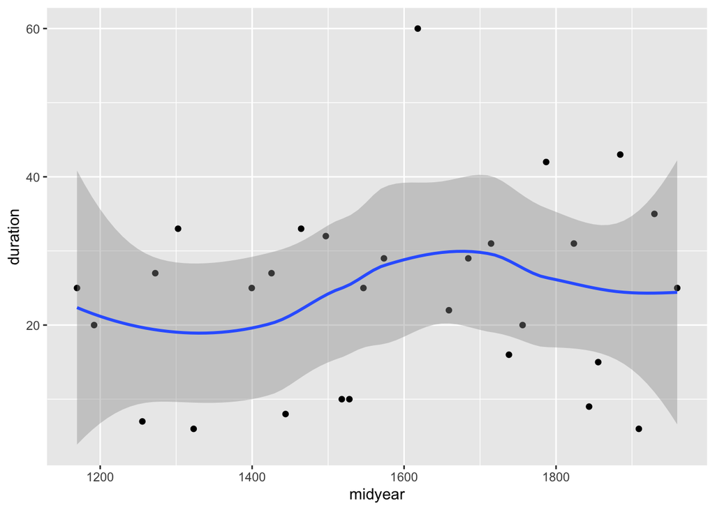

```r
kingsduration %>%
  na.omit(kingsduration$midyear) %>%
  ggplot(aes(x=midyear, y=duration))+
  geom_point()+
  geom_smooth()
```

And to submit this rmarkdown, knit it into html. But first, clean up the code chunks, adjust the date, rename the author and change the `eval=FALSE` flag to `eval=TRUE` so your script actually generates an output. Well done!